# BIG5 Selector: Data Audit and Validation EDA

This report reads the official BIG5-CHAT source CSV itself, verifies its bytes and SHA-256 against the pinned source manifest, and then audits the Python-prepared classifier table. It does not claim that R produced the cleaned table.

## Official source audit

```r
raw_table <- data.frame(
  source = "wenkai-li/big5_chat",
  revision = manifest$revision,
  observed_rows = format(raw_rows, scientific = FALSE, trim = TRUE),
  kept_rows = format(nrow(rows), scientific = FALSE, trim = TRUE),
  excluded_rows = format(cleaning$excluded_rows, scientific = FALSE, trim = TRUE),
  observed_bytes = format(raw_bytes, scientific = FALSE, trim = TRUE),
  manifest_bytes = format(manifest$bytes, scientific = FALSE, trim = TRUE),
  sha256_match = raw_sha256 == manifest$sha256
)
knitr::kable(raw_table, digits = 0,
             caption = "Official BIG5-CHAT source verified against the pinned manifest and cleaning audit")
```

Official BIG5-CHAT source verified against the pinned manifest and cleaning audit

| source | revision | observed_rows | kept_rows | excluded_rows | observed_bytes | manifest_bytes | sha256_match |
| --- | --- | --- | --- | --- | --- | --- | --- |
| wenkai-li/big5_chat | adf1cd37997b498ff7b220827eaacdeb8aa6d905 | 100000 | 99656 | 344 | 88551712 | 88551712 | TRUE |

## Prepared classifier table

This R preprocessing step reconstructs the missing-text exclusions directly from the raw file. It also selects the allowed classroom analysis fields explicitly, leaving out `train_instruction`, which contains the requested personality label. The transitive scenario grouping is implemented separately in Python and audited below.

```r
pmr_require_columns(raw, c("train_input", "train_output", "trait", "level", "original_index"))
has_input <- pmr_nonempty(raw$train_input)
has_response <- pmr_nonempty(raw$train_output)
clean_text <- raw[has_input & has_response,
                  c("original_index", "train_input", "train_output", "trait", "level")]
clean_text$label <- paste(clean_text$trait, clean_text$level, sep = "_")
if (nrow(clean_text) != cleaning$kept_rows || any(!clean_text$label %in% SELECTOR_CLASSES))
  stop("R missing-text cleaning disagrees with the prepared table.")
knitr::kable(data.frame(check = c("Missing input", "Missing response", "Missing both", "Excluded union", "Retained"),
                       rows = c(sum(!has_input), sum(!has_response), sum(!has_input & !has_response),
                                sum(!has_input | !has_response), nrow(clean_text))),
             caption = "R reconstructs missing-value exclusions without imputation")
```

R reconstructs missing-value exclusions without imputation

| check | rows |
| --- | --- |
| Missing input | 294 |
| Missing response | 65 |
| Missing both | 15 |
| Excluded union | 344 |
| Retained | 99656 |

```r
prepared <- as.data.frame(xtabs(~ split + role, rows))
knitr::kable(prepared, caption = "Prepared selector rows by split and role")
```

Prepared selector rows by split and role

| split | role | Freq |
| --- | --- | --- |
| test | memory | 7226 |
| train | memory | 0 |
| val | memory | 7827 |
| test | query | 7351 |
| train | query | 0 |
| val | query | 7469 |
| test | train | 0 |
| train | train | 69783 |
| val | train | 0 |

```r
labels <- as.data.frame(xtabs(~ split + label, rows))
knitr::kable(labels, caption = "BIG5 class balance by prepared split")
```

BIG5 class balance by prepared split

| split | label | Freq |
| --- | --- | --- |
| test | agreeableness_high | 1459 |
| train | agreeableness_high | 6979 |
| val | agreeableness_high | 1530 |
| test | agreeableness_low | 1459 |
| train | agreeableness_low | 6982 |
| val | agreeableness_low | 1530 |
| test | conscientiousness_high | 1458 |
| train | conscientiousness_high | 6979 |
| val | conscientiousness_high | 1530 |
| test | conscientiousness_low | 1458 |
| train | conscientiousness_low | 6980 |
| val | conscientiousness_low | 1530 |
| test | extraversion_high | 1459 |
| train | extraversion_high | 6983 |
| val | extraversion_high | 1530 |
| test | extraversion_low | 1455 |
| train | extraversion_low | 6965 |
| val | extraversion_low | 1527 |
| test | neuroticism_high | 1458 |
| train | neuroticism_high | 6980 |
| val | neuroticism_high | 1529 |
| test | neuroticism_low | 1458 |
| train | neuroticism_low | 6976 |
| val | neuroticism_low | 1530 |
| test | openness_high | 1458 |
| train | openness_high | 6981 |
| val | openness_high | 1530 |
| test | openness_low | 1455 |
| train | openness_low | 6978 |
| val | openness_low | 1530 |

```r
groups <- aggregate(row_id ~ split + group_id, rows, length)
group_summary <- do.call(rbind, lapply(split(groups$row_id, groups$split), function(x)
  data.frame(groups = length(x), min_rows = min(x), median_rows = median(x), max_rows = max(x))))
group_summary$split <- rownames(group_summary); rownames(group_summary) <- NULL
knitr::kable(group_summary[c("split", "groups", "min_rows", "median_rows", "max_rows")],
             caption = "Group counts and rows per group after preparation")
```

Group counts and rows per group after preparation

| split | groups | min_rows | median_rows | max_rows |
| --- | --- | --- | --- | --- |
| test | 1239 | 4 | 10 | 40 |
| train | 5853 | 1 | 10 | 270 |
| val | 1288 | 9 | 10 | 90 |

The classifier contract requires each `group_id` to occur in exactly one split. The validation above stops rendering if this invariant, the fixed ten-class vocabulary, or unique `row_id` values fail.

## Training-text length and group size

These plots use training rows. Length means Unicode characters, not language-model tokens. The logarithmic length axis preserves the long tail without dropping records.

```r
training <- rows[rows$split == "train", ]
response_chars <- nchar(training$model_response, type = "chars")
knitr::kable(data.frame(percentile = c("minimum", "median", "90%", "99%", "maximum"),
                       characters = as.numeric(quantile(response_chars, c(0, .5, .9, .99, 1)))),
             caption = "Target response length in training data")
```

Target response length in training data

| percentile | characters |
| --- | --- |
| minimum | 2.00 |
| median | 234.00 |
| 90% | 273.00 |
| 99% | 305.18 |
| maximum | 392.00 |

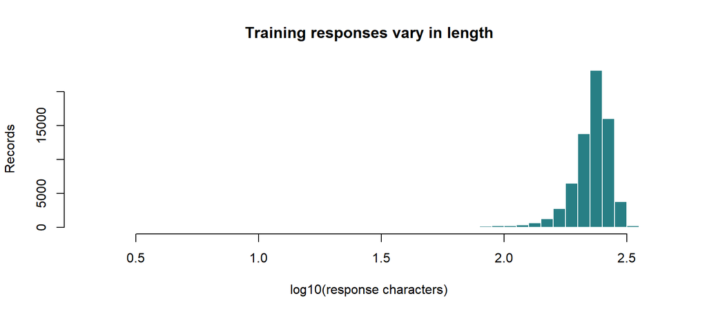

```r
hist(log10(pmax(response_chars, 1)), breaks = 35, col = "#287F85", border = "white",
     main = "Training responses vary in length", xlab = "log10(response characters)", ylab = "Records")
```

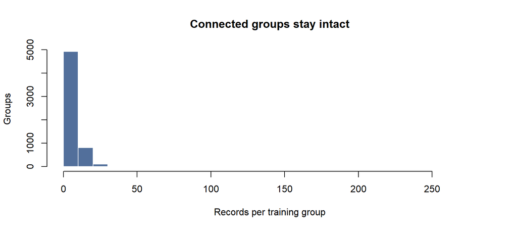

```r
group_size <- groups$row_id[groups$split == "train"]
hist(group_size, breaks = seq(0, max(group_size) + 10, by = 10), col = "#526F9B", border = "white",
     main = "Connected groups stay intact", xlab = "Records per training group", ylab = "Groups")
```

## Validation-only model comparison

```r
metrics_path <- file.path(root, "artifacts", "selector", "validation_metrics.csv")
if (file.exists(metrics_path)) {
  metrics <- pmr_read_csv(metrics_path)
  metrics$validation_macro_f1 <- as.numeric(metrics$validation_macro_f1)
  knitr::kable(metrics[order(-metrics$validation_macro_f1), ], digits = 4,
               caption = "Candidate selection using validation Macro-F1 only")
} else {
  cat("Training outputs are not present yet. This section intentionally reports no test result.")
}
```

Candidate selection using validation Macro-F1 only

|  | candidate | validation_macro_f1 | selected |
| --- | --- | --- | --- |
| 3 | response_glmnet | 0.5829 | TRUE |
| 5 | tfidf_glmnet | 0.5802 | FALSE |
| 4 | response_rf | 0.4452 | FALSE |
| 1 | context_glmnet | 0.3969 | FALSE |
| 2 | context_rf | 0.2697 | FALSE |

Test labels are not read or summarized as model results here. The separate evaluation entry point remains locked until a hash-pinned frozen marker exists.

## Which validation labels are confused?

The following chart uses only validation predictions from the selected offline classifier. Rows are generation targets; columns are predictions. Colors show the fraction within each target class, and the printed values are record counts. A/C/E/N/O stand for agreeableness, conscientiousness, extraversion, neuroticism, and openness; + and - mean high and low.

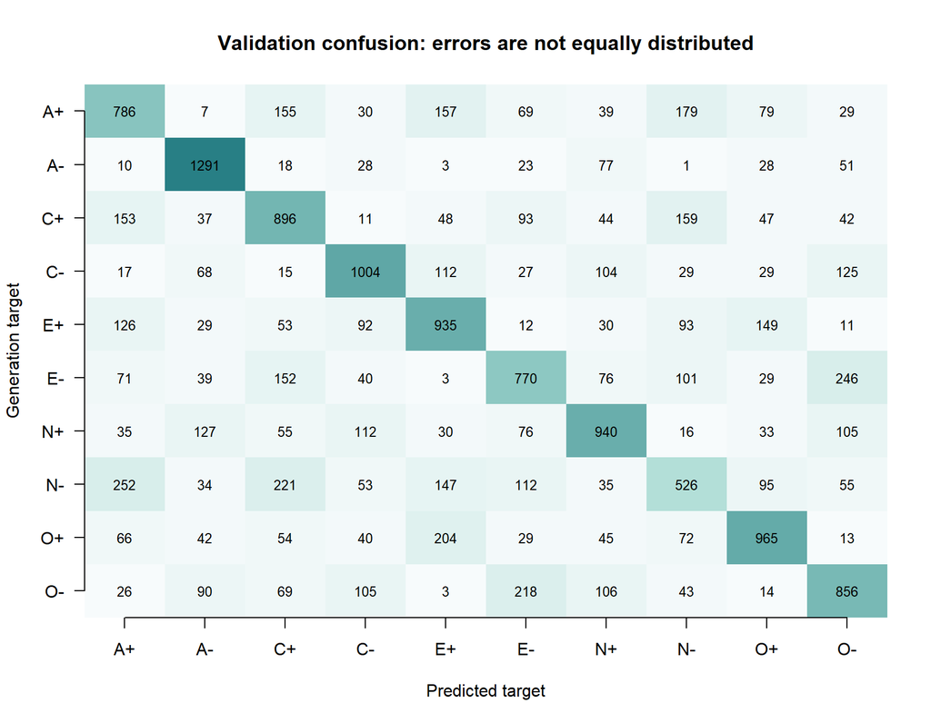

Validation precision and recall by generation target

|  | class | support | precision | recall | f1 |
| --- | --- | --- | --- | --- | --- |
| selected.1 | agreeableness_high | 1530 | 0.510 | 0.514 | 0.512 |
| selected.2 | agreeableness_low | 1530 | 0.732 | 0.844 | 0.784 |
| selected.3 | conscientiousness_high | 1530 | 0.531 | 0.586 | 0.557 |
| selected.4 | conscientiousness_low | 1530 | 0.663 | 0.656 | 0.659 |
| selected.5 | extraversion_high | 1530 | 0.569 | 0.611 | 0.590 |
| selected.6 | extraversion_low | 1527 | 0.539 | 0.504 | 0.521 |
| selected.7 | neuroticism_high | 1529 | 0.628 | 0.615 | 0.621 |
| selected.8 | neuroticism_low | 1530 | 0.432 | 0.344 | 0.383 |
| selected.9 | openness_high | 1530 | 0.657 | 0.631 | 0.644 |
| selected.10 | openness_low | 1530 | 0.558 | 0.559 | 0.559 |

Classifier confidence versus observed validation accuracy

|  | confidence_bin | count | mean_confidence | accuracy |
| --- | --- | --- | --- | --- |
| selected.1 | 0.0-0.1 | 0 | NA | NA |
| selected.2 | 0.1-0.2 | 126 | 0.182 | 0.222 |
| selected.3 | 0.2-0.3 | 1721 | 0.262 | 0.275 |
| selected.4 | 0.3-0.4 | 3144 | 0.350 | 0.390 |
| selected.5 | 0.4-0.5 | 2742 | 0.448 | 0.518 |
| selected.6 | 0.5-0.6 | 2203 | 0.547 | 0.622 |
| selected.7 | 0.6-0.7 | 1632 | 0.648 | 0.711 |
| selected.8 | 0.7-0.8 | 1409 | 0.750 | 0.805 |
| selected.9 | 0.8-0.9 | 1205 | 0.849 | 0.900 |
| selected.10 | 0.9-1.0 | 1114 | 0.947 | 0.961 |

```r
probability_path <- file.path(root, "artifacts", "selector", "val_probabilities.csv")
if (file.exists(probability_path)) {
  saved <- pmr_read_csv(probability_path)
  pmr_require_columns(saved, c("row_id", SELECTOR_CLASSES))
  expected <- rows[rows$split == "val", ]
  if (anyDuplicated(saved$row_id) || !setequal(saved$row_id, expected$row_id))
    stop("Validation predictions do not match validation row identities.")
  saved <- saved[match(expected$row_id, saved$row_id), ]
  probability <- as.matrix(saved[SELECTOR_CLASSES]); storage.mode(probability) <- "double"
  predicted <- selector_classify(probability)
  counts <- table(factor(expected$label, levels = SELECTOR_CLASSES),
                  factor(predicted, levels = SELECTOR_CLASSES))
  fractions <- sweep(counts, 1L, rowSums(counts), "/")
  labels <- c("A+", "A-", "C+", "C-", "E+", "E-", "N+", "N-", "O+", "O-")
  image(1:10, 1:10, t(fractions)[, 10:1], axes = FALSE,
        col = colorRampPalette(c("#F7FBFC", "#A4D9D0", "#287F85"))(50),
        xlab = "Predicted target", ylab = "Generation target",
        main = "Validation confusion: errors are not equally distributed")
  axis(1, at = 1:10, labels = labels); axis(2, at = 1:10, labels = rev(labels), las = 1)
  text(rep(1:10, 10), rep(1:10, each = 10), labels = as.vector(t(counts)[, 10:1]), cex = .8)
  tables <- selector_evaluation_tables(list(selected = probability), expected$label, "selected", "selected")
  print(knitr::kable(tables$per_class[c("class", "support", "precision", "recall", "f1")], digits = 3, format = "html",
               caption = "Validation precision and recall by generation target"))
  print(knitr::kable(tables$confidence[c("confidence_bin", "count", "mean_confidence", "accuracy")], digits = 3, format = "html",
               caption = "Classifier confidence versus observed validation accuracy"))
} else {
  cat("Validation predictions are pending; no confusion pattern is inferred.")
}
```